# Feature Optimization for Coffee Adulteration Detection Using Hyperspectral Imaging and Linear Discriminant Analysis (LDA): Genetic Algorithm Using Raw Spectra Data

## Define the Fitness Function for GA

- This function evaluates subsets of features selected by GA using RFE with a Random Forest (RF) model.

```r
# Detect the number of cores
num_cores <- detectCores()
# Print the number of cores
print(paste("Number of cores available:", num_cores))
```

```
[1] "Number of cores available: 8"
```

```r
# Fitness Function
fitness_ga_rfe <- function(subset) {
  # Identify selected features based on the binary subset
  selected_features <- which(subset == 1)

  # Penalize empty subsets to avoid errors
  if (length(selected_features) == 0) return(Inf)

  # Subset the training feature matrix to selected features
  X_selected <- X_train[, selected_features]

  # Define control for rfe
  control <- rfeControl(functions = rfFuncs,  # Use Random Forest for rfe
                        method = "cv",       # Cross-validation
                        number = 10)         # 10-fold CV

  # Apply rfe to the selected subset of features
  rfe_result <- rfe(X_selected, y_train, rfeControl = control)

  # Return the negative accuracy as the fitness score (to maximize accuracy)
  return(-rfe_result$results$Accuracy[which.max(rfe_result$results$Accuracy)])
}
```

## Run the Genetic Algorithm

```r
# Set seed for reproducibility
set.seed(123)

num_features <- ncol(X_train) # Number of features
dataset_name <- "raw"   # Set the dataset name dynamically

# Define paths for the execution flag and GA result
flag_file <- paste0("ga_executed_flag_", dataset_name, ".RData")
result_file <- paste0("ga_result_", dataset_name, ".RData")

# Check if the result file exists
if (!file.exists(result_file)) {
  message("No result file found. Running the Genetic Algorithm (GA).")

  # Register cluster for caret to train the models in parallel
  cl <- makeCluster(6, type = "SOCK")
  suppressWarnings(suppressMessages(registerDoSNOW(cl)))

  # Register start time
  start_time <- Sys.time()

  # Run the Genetic Algorithm
  ga_result <- ga(
    type = "binary",
    fitness = fitness_ga_rfe,
    nBits = num_features,             # Number of features
    popSize = 20,                     # Population size
    maxiter = 50,                     # Maximum iterations
    run = 10,                         # Convergence stopping criterion
    names = colnames(train_data[, -ncol(train_data)]),  # Feature names
    pcrossover = 0.8,                 # Probability of crossover
    pmutation = 0.1,                  # Probability of mutation
    maxFitness = -0.9,                # Stop when fitness reaches target
    parallel = TRUE,                  # Enable parallel processing
    monitor = gaMonitor,              # Track progress
    seed = 123                        # Reproducibility
  )

  # Stop the cluster
  stopCluster(cl)

  # Register end time
  end_time <- Sys.time()
  print(paste('Time to run the GA model:', end_time - start_time))

  # Save the GA result and execution flag
  ga_executed <- TRUE
  save(ga_executed, ga_result, file = result_file)  # Save both flag and results

  message("GA execution completed and results saved.")

} else {
  # Load previously saved results
  message("Result file found. Loading saved GA results.")
  load(result_file)
  message(paste("GA already executed for dataset:", dataset_name))
}
```

```
Result file found. Loading saved GA results.
```

```
GA already executed for dataset: raw
```

## Visualization Plot

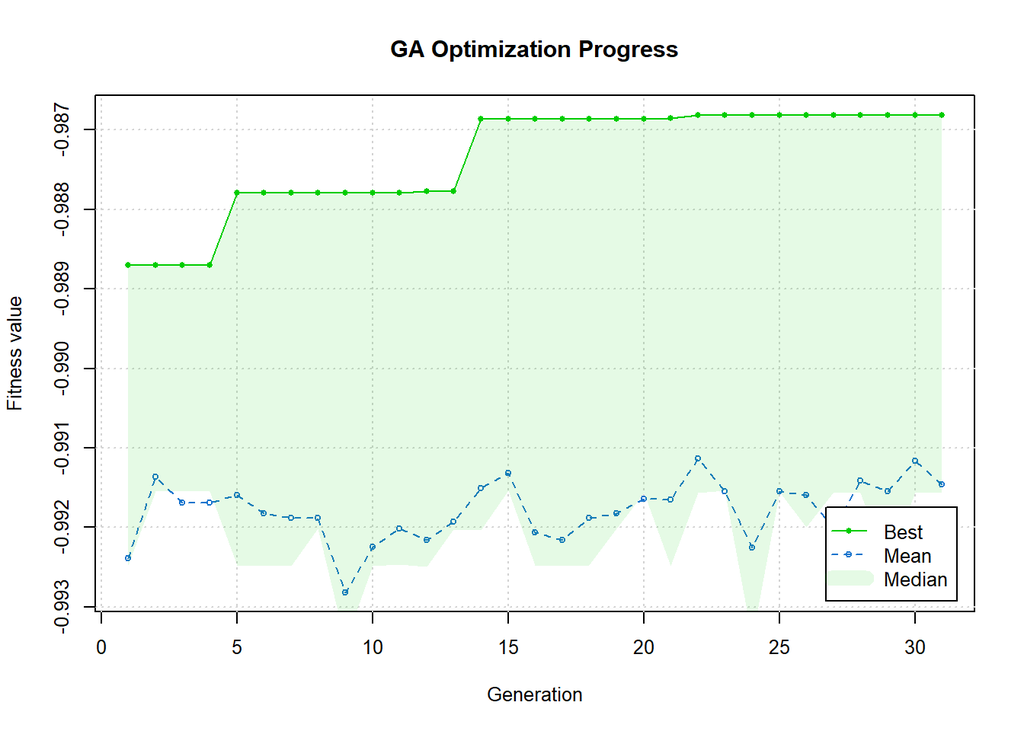

```r
par (cex = 0.8)
plot(ga_result, main = "GA Optimization Progress")
```

```r
par(cex = 1)
```

## Analyze GA results

```r
summary(ga_result)
```

```
── Genetic Algorithm ───────────────────

GA settings:
Type                  =  binary
Population size       =  20
Number of generations =  50
Elitism               =  1
Crossover probability =  0.8
Mutation probability  =  0.1

GA results:
Iterations             = 31
Fitness function value = -0.9868092
Solution =
     X935.609985 X939.059998 X942.52002 X945.97998 X949.429993 X952.890015
[1,]           1           0          0          1           0           0
     X956.349976 X959.809998 X963.27002 X966.72998  ...  X1716.650024
[1,]           0           0          0          1                  1
     X1720.22998
[1,]           1
```

## Post-Selection

```r
# Get the best feature subset
best_features <- which(ga_result@solution == 1)
selected_feature_names <- colnames(train_data)[best_features]
print(selected_feature_names)
```

```
  [1] "X935.609985"  "X945.97998"   "X966.72998"   "X970.190002"  "X973.650024"
  [6] "X977.109985"  "X1018.710022" "X1022.179993" "X1025.650024" "X1029.119995"
 [11] "X1032.589966" "X1046.47998"  "X1056.900024" "X1060.380005" "X1063.849976"
 [16] "X1070.810059" "X1081.23999"  "X1088.199951" "X1098.650024" "X1112.579956"
 [21] "X1116.069946" "X1119.550049" "X1123.040039" "X1136.98999"  "X1140.469971"
 [26] "X1143.959961" "X1157.930054" "X1164.910034" "X1178.890015" "X1182.380005"
 [31] "X1189.369995" "X1196.369995" "X1199.869995" "X1210.369995" "X1213.869995"
 [36] "X1220.869995" "X1224.369995" "X1234.880005" "X1238.390015" "X1241.890015"
 [41] "X1245.400024" "X1252.410034" "X1262.930054" "X1266.439941" "X1273.459961"
 [46] "X1283.98999"  "X1291.02002"  "X1298.050049" "X1301.560059" "X1305.079956"
 [51] "X1312.109985" "X1329.699951" "X1333.219971" "X1336.73999"  "X1343.780029"
 [56] "X1350.819946" "X1354.349976" "X1361.390015" "X1368.439941" "X1371.969971"
 [61] "X1379.02002"  "X1386.079956" "X1393.140015" "X1403.72998"  "X1410.790039"
 [66] "X1414.319946" "X1417.859985" "X1421.390015" "X1428.459961" "X1435.530029"
 [71] "X1439.069946" "X1442.599976" "X1453.219971" "X1456.76001"  "X1460.300049"
 [76] "X1463.839966" "X1478.01001"  "X1481.550049" "X1488.640015" "X1492.180054"
 [81] "X1495.72998"  "X1499.27002"  "X1517.01001"  "X1531.209961" "X1534.76001"
 [86] "X1538.319946" "X1541.869995" "X1548.97998"  "X1552.530029" "X1563.199951"
 [91] "X1566.75"     "X1573.869995" "X1577.430054" "X1591.670044" "X1598.790039"
 [96] "X1602.349976" "X1609.47998"  "X1620.170044" "X1627.310059" "X1630.869995"
[101] "X1634.439941" "X1638.01001"  "X1641.579956" "X1645.150024" "X1655.859985"
[106] "X1659.430054" "X1666.569946" "X1673.719971" "X1677.290039" "X1680.869995"
[111] "X1688.02002"  "X1695.170044" "X1702.329956" "X1713.069946" "X1716.650024"
[116] "X1720.22998"
```

```r
print(paste('The number of selected variables are', length(selected_feature_names)))
```

```
[1] "The number of selected variables are 116"
```

```r
n_selected <- as.numeric(length(selected_feature_names))
```

## Create a Data frame with the Selected Features

```r
# Subset the training and test data using the selected features
X_train_selected <- X_train[, selected_feature_names, drop = FALSE]
X_test_selected <- X_test[, selected_feature_names, drop = FALSE]

# Keep y_train and y_test as-is
y_train_selected <- y_train
y_test_selected <- y_test


#Merge data_frame
train_merged <- cbind(X_train_selected, binary_class = y_train_selected)
test_merged <- cbind(X_test_selected, binary_class = y_test_selected)

dim(train_merged)
```

```
[1] 1065  117
```

```r
dim(test_merged)
```

```
[1] 411 117
```

```r
table(train_merged$binary_class)
```

```
 adulterated pure_arabica
        1017           48
```

```r
table(test_merged$binary_class)
```

```
 adulterated pure_arabica
         384           27
```

## Create a Data frame with the Selected Features for SMOTE Data

```r
X_train_selected_smote <- X_train_smote[,selected_feature_names, drop = FALSE]
X_test_selected_smote <- X_test[, selected_feature_names, drop = FALSE]

# Keep y_train and y_test as-is
y_train_selected_smote <- y_train
y_test_selected_smote <- y_test

#Merge data_frame
train_merged_smote <- cbind(X_train_selected_smote, binary_class = smote_data$binary_class)
test_merged_smote <- cbind(X_test_selected_smote, binary_class = y_test_selected_smote)

dim(train_merged_smote)
```

```
[1] 1872  117
```

```r
dim(test_merged_smote)
```

```
[1] 411 117
```

```r
table(train_merged_smote$binary_class)
```

```
 adulterated pure_arabica
         912          960
```

```r
table(test_merged_smote$binary_class)
```

```
 adulterated pure_arabica
         384           27
```

## Check correlations by HeatMaps

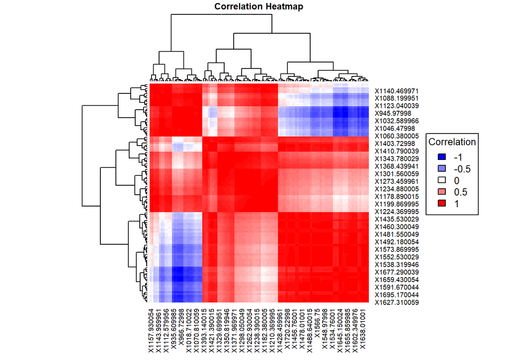

```r
# Calculate the correlation matrix

#Imbalanced Data

#Calculate correlations
corr <- cor(train_merged[, -(n_selected+1)])

# Create a heat map
par(cex.main = 0.6)
heatmap(corr, symm = TRUE,
        col = colorRampPalette(c("blue", "white", "red"))(50),
        main = "Correlation Heatmap")

# Add legend

legend("right",
       legend = seq(-1, 1, by = 0.5),  # Correlation range
       fill = colorRampPalette(c("blue", "white", "red"))(5),
       title = "Correlation", cex = 0.8)
```

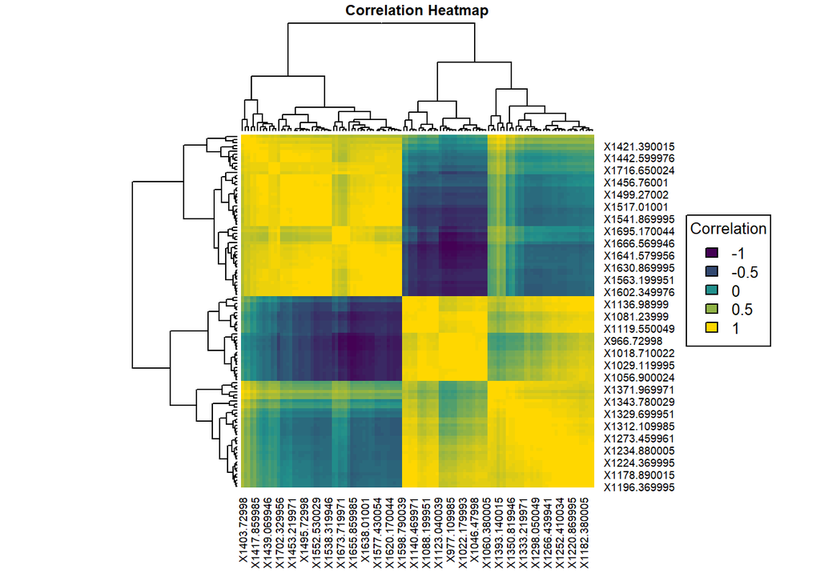

```r
# SMOTE Data
par(cex.main = 0.6)
corr <- cor(train_merged_smote[, -(n_selected+1)])
# Create heat map
heatmap(corr, symm = TRUE,
        col = colorRampPalette(c("#440154", "#21908C", "gold"))(50),
        main = 'Correlation Heatmap',cex.main = 0.6)

# Add legend
legend("right",
       legend = seq(-1, 1, by = 0.5),  # Correlation range
       fill = colorRampPalette(c("#440154", "#21908C", "gold"))(5),
       title = "Correlation",
       cex = 0.8)
```

- The correlation heat maps reveal that some variables remain highly correlated. To address this issue and mitigate multicollinearity, we will employ Principal Component Analysis (PCA). We will then proceed to train our models with features generated by PCA. This aims to speed up processing time.

## PreProcess by PCA, Centering and Scaling Data

```r
# Imbalanced Data
pca_Preprocess <- preProcess(train_merged, method = c("center", "scale", "pca"))
train_mergedPreprocessed <- predict(pca_Preprocess, train_merged) # train data
test_mergedPreprocessed <- predict(pca_Preprocess,test_merged) # apply on test data

# SMOTE Data
pca_Preprocess_smote <- preProcess(train_merged_smote,method = c("center", "scale", "pca"))
train_merged_smote_Preprocessed <- predict(pca_Preprocess_smote,train_merged_smote)
test_merged_smote_Preprocessed <- predict(pca_Preprocess_smote,test_merged_smote)

# Check dimensions of the preprocessed data to ensure consistency

dim(train_mergedPreprocessed)
```

```
[1] 1065    3
```

```r
dim(test_mergedPreprocessed)
```

```
[1] 411   3
```

```r
dim(train_merged_smote_Preprocessed)
```

```
[1] 1872    3
```

```r
dim(test_merged_smote_Preprocessed)
```

```
[1] 411   3
```

## Set Up Training Parameters

```r
# Set random seed for reproducibility

set.seed (123)

# Set up the training control(10 folds 10 times cross_validation)
control <- trainControl(method = "repeatedcv", number = 10, repeats = 10,
                        classProbs = TRUE, savePredictions = "final",
                        summaryFunction = multiClassSummary,
                        selectionFunction = 'oneSE')

# One SE rule will be used to select simplest yet optimal model within the 'best model'
```

```r
#Set the metric as accuracy
metric<-"Accuracy"
```

## Train the Models

```r
set.seed(123)

# Start_time
start_time<-Sys.time()

#Train the model using cross-validation (10 folds, 10 times)
fit_lda_raw<-train(binary_class ~.,
                      data = train_mergedPreprocessed,
                      method = 'lda',
                      trControl = control, metric = 'Accuracy')  #unmodified data
end_time<-Sys.time() #End_time

model_training_time<-end_time-start_time

print(model_training_time) # Time taken to run the model
```

```
Time difference of 1.718113 secs
```

```r
print(fit_lda_raw) # Model on imbalanced data
```

```
Linear Discriminant Analysis

1065 samples
   2 predictor
   2 classes: 'adulterated', 'pure_arabica'

No pre-processing
Resampling: Cross-Validated (10 fold, repeated 10 times)
Summary of sample sizes: 958, 959, 958, 960, 958, 959, ...
Resampling results:

  logLoss    AUC        prAUC      Accuracy   Kappa        F1
  0.1649244  0.7124293  0.5839374  0.9551301  0.007135894  0.9770427
  Sensitivity  Specificity  Pos_Pred_Value  Neg_Pred_Value  Precision  Recall
  1            0.0045       0.9551239       1               0.9551239  1
  Detection_Rate  Balanced_Accuracy
  0.9549423       0.50225
```

```r
#Register cluster for caret to train the models in parallel
set.seed(123)

# Fit the model
fit_lda_smote_raw<-train(binary_class~.,
                            data = train_merged_smote_Preprocessed,
                            method ='lda',
                            trControl = control, metric = 'Accuracy')# SMOTE data
#End_time
end_time<-Sys.time()

model_training_time<-end_time-start_time # Time taken to run the model


print(model_training_time)
```

```
Time difference of 3.797185 secs
```

```r
print(fit_lda_smote_raw)
```

```
Linear Discriminant Analysis

1872 samples
   2 predictor
   2 classes: 'adulterated', 'pure_arabica'

No pre-processing
Resampling: Cross-Validated (10 fold, repeated 10 times)
Summary of sample sizes: 1684, 1685, 1685, 1685, 1685, 1685, ...
Resampling results:

  logLoss    AUC        prAUC      Accuracy   Kappa      F1         Sensitivity
  0.5719229  0.7674227  0.7813123  0.6577901  0.3169251  0.6659305  0.7003261
  Specificity  Pos_Pred_Value  Neg_Pred_Value  Precision  Recall
  0.6173958    0.6357639       0.6846654       0.6357639  0.7003261
  Detection_Rate  Balanced_Accuracy
  0.3411836       0.658861
```

## Save the models for future use

```r
saveRDS(fit_lda_raw, "fit_lda_raw.rds")
saveRDS(fit_lda_smote_raw, "fit_lda_smote_raw.rds")
```

## Display the cross-validation results

```r
# Imbalanced data
kable(fit_lda_raw$results,
      caption = "Cross-Validation Results on Imbalanced Data")
```

Cross-Validation Results on Imbalanced Data

| parameter | logLoss | AUC | prAUC | Accuracy | Kappa | F1 | Sensitivity | Specificity | Pos_Pred_Value | Neg_Pred_Value | Precision | Recall | Detection_Rate | Balanced_Accuracy | logLossSD | AUCSD | prAUCSD | AccuracySD | KappaSD | F1SD | SensitivitySD | SpecificitySD | Pos_Pred_ValueSD | Neg_Pred_ValueSD | PrecisionSD | RecallSD | Detection_RateSD | Balanced_AccuracySD |
| --- | --- | --- | --- | --- | --- | --- | --- | --- | --- | --- | --- | --- | --- | --- | --- | --- | --- | --- | --- | --- | --- | --- | --- | --- | --- | --- | --- | --- |
| none | 0.1649244 | 0.7124293 | 0.5839374 | 0.9551301 | 0.0071359 | 0.9770427 | 1 | 0.0045 | 0.9551239 | 1 | 0.9551239 | 1 | 0.9549423 | 0.50225 | 0.0280696 | 0.1391045 | 0.0840849 | 0.0040008 | 0.0504351 | 0.0020768 | 0 | 0.0318575 | 0.003983 | 0 | 0.003983 | 0 | 0.0036305 | 0.0159287 |

```r
# SMOTE Data
kable(fit_lda_smote_raw$results,
      caption = "Cross-Validation Results on SMOTE Data")
```

Cross-Validation Results on SMOTE Data

| parameter | logLoss | AUC | prAUC | Accuracy | Kappa | F1 | Sensitivity | Specificity | Pos_Pred_Value | Neg_Pred_Value | Precision | Recall | Detection_Rate | Balanced_Accuracy | logLossSD | AUCSD | prAUCSD | AccuracySD | KappaSD | F1SD | SensitivitySD | SpecificitySD | Pos_Pred_ValueSD | Neg_Pred_ValueSD | PrecisionSD | RecallSD | Detection_RateSD | Balanced_AccuracySD |
| --- | --- | --- | --- | --- | --- | --- | --- | --- | --- | --- | --- | --- | --- | --- | --- | --- | --- | --- | --- | --- | --- | --- | --- | --- | --- | --- | --- | --- |
| none | 0.5719229 | 0.7674227 | 0.7813123 | 0.6577901 | 0.3169251 | 0.6659305 | 0.7003261 | 0.6173958 | 0.6357639 | 0.6846654 | 0.6357639 | 0.7003261 | 0.3411836 | 0.658861 | 0.0281345 | 0.0302943 | 0.0250151 | 0.0315951 | 0.0627773 | 0.0298668 | 0.0391366 | 0.0481548 | 0.032613 | 0.0337221 | 0.032613 | 0.0391366 | 0.0191059 | 0.0314074 |

## Confusion matrix for the training data

```r
confusionMatrix(fit_lda_raw$pred$pred,
                fit_lda_raw$pred$obs) # unmodified data
```

```
Confusion Matrix and Statistics

              Reference
Prediction     adulterated pure_arabica
  adulterated        10170          478
  pure_arabica           0            2

               Accuracy : 0.9551
                 95% CI : (0.951, 0.959)
    No Information Rate : 0.9549
    P-Value [Acc > NIR] : 0.4749

                  Kappa : 0.0079

 Mcnemar's Test P-Value : <2e-16

            Sensitivity : 1.000000
            Specificity : 0.004167
         Pos Pred Value : 0.955109
         Neg Pred Value : 1.000000
             Prevalence : 0.954930
         Detection Rate : 0.954930
   Detection Prevalence : 0.999812
      Balanced Accuracy : 0.502083

       'Positive' Class : adulterated
```

```r
confusionMatrix(fit_lda_smote_raw$pred$pred,
                fit_lda_smote_raw$pred$obs) # SMOTE data
```

```
Confusion Matrix and Statistics

              Reference
Prediction     adulterated pure_arabica
  adulterated         6387         3673
  pure_arabica        2733         5927

               Accuracy : 0.6578
                 95% CI : (0.651, 0.6646)
    No Information Rate : 0.5128
    P-Value [Acc > NIR] : < 2.2e-16

                  Kappa : 0.3169

 Mcnemar's Test P-Value : < 2.2e-16

            Sensitivity : 0.7003
            Specificity : 0.6174
         Pos Pred Value : 0.6349
         Neg Pred Value : 0.6844
             Prevalence : 0.4872
         Detection Rate : 0.3412
   Detection Prevalence : 0.5374
      Balanced Accuracy : 0.6589

       'Positive' Class : adulterated
```

LDA Plot for Unmodified Data

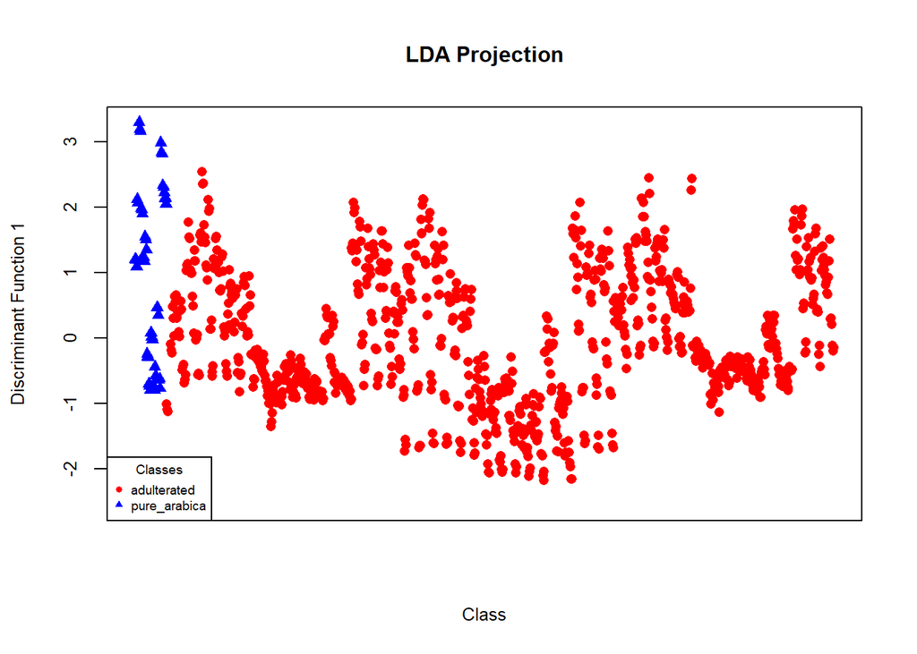

```r
# Project training data onto LDA components # unmodified Data

lda_projection <- predict(fit_lda_raw$finalModel,
                          train_mergedPreprocessed[,-1])

# Convert LDA results to a data frame
lda_data <- data.frame(
  Discriminant1 = lda_projection$x[, 1],
  Class = train_mergedPreprocessed[, 1])

# Set the color and shape
group_colors <- c("red", "blue")
group_shapes <- c(16, 17)

# Plot the data
plot(lda_data$Discriminant1,
     col = group_colors[as.numeric(train_mergedPreprocessed[, 1])],
     pch = group_shapes[as.numeric(train_mergedPreprocessed[, 1])],
     xlab = "Class",
     ylab = "Discriminant Function 1",
     main = "LDA Projection", cex.main = 1.0,
     cex.axis = 0.8, cex.lab = 0.8, xaxt = "n")
# Add a legend
legend("bottomleft", legend = levels(train_mergedPreprocessed[, 1]),
       col = group_colors, pch = group_shapes, title = "Classes", cex = 0.6)
```

LDA Plot for SMOTE Data

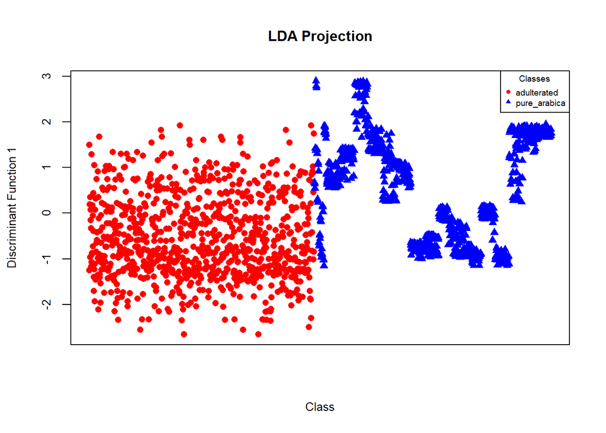

```r
# Project training data onto LDA components # unmodified Data

lda_projection <- predict(fit_lda_raw$finalModel,
                          train_merged_smote_Preprocessed[,-1])

# Convert LDA results to a data frame
lda_data <- data.frame(
  Discriminant1 = lda_projection$x[, 1],
  Class = train_merged_smote_Preprocessed[, 1])

# Set the color and shape
group_colors <- c("red", "blue")
group_shapes <- c(16, 17)

# Plot the data
plot(lda_data$Discriminant1,
     col = group_colors[as.numeric(train_merged_smote_Preprocessed[, 1])],
     pch = group_shapes[as.numeric(train_merged_smote_Preprocessed[, 1])],
     xlab = "Class",
     ylab = "Discriminant Function 1",
     main = "LDA Projection", cex.main = 1.0,
     cex.axis = 0.8, cex.lab = 0.8, xaxt = "n")
# Add a legend
legend("topright", legend = levels(train_merged_smote_Preprocessed[, 1]),
       col = group_colors, pch = group_shapes, title = "Classes", cex = 0.6)
```

## Test the model performance on test data for imbalanced trained data

```r
# Predict on the test set

test_lda_unmodified <- predict(fit_lda_raw,newdata=test_mergedPreprocessed)

# Get the confusion matrix
test_lda_unmodified_CMtrx <- confusionMatrix(test_lda_unmodified,
                                             test_mergedPreprocessed$binary_class)
test_lda_unmodified_CMtrx
```

```
Confusion Matrix and Statistics

              Reference
Prediction     adulterated pure_arabica
  adulterated          384           27
  pure_arabica           0            0

               Accuracy : 0.9343
                 95% CI : (0.9059, 0.9563)
    No Information Rate : 0.9343
    P-Value [Acc > NIR] : 0.551

                  Kappa : 0

 Mcnemar's Test P-Value : 5.624e-07

            Sensitivity : 1.0000
            Specificity : 0.0000
         Pos Pred Value : 0.9343
         Neg Pred Value :    NaN
             Prevalence : 0.9343
         Detection Rate : 0.9343
   Detection Prevalence : 1.0000
      Balanced Accuracy : 0.5000

       'Positive' Class : adulterated
```

```r
knitr::kable(test_lda_unmodified_CMtrx$byClass)
```

|  | x |
| --- | --- |
| Sensitivity | 1.0000000 |
| Specificity | 0.0000000 |
| Pos Pred Value | 0.9343066 |
| Neg Pred Value | NaN |
| Precision | 0.9343066 |
| Recall | 1.0000000 |
| F1 | 0.9660377 |
| Prevalence | 0.9343066 |
| Detection Rate | 0.9343066 |
| Detection Prevalence | 1.0000000 |
| Balanced Accuracy | 0.5000000 |

```r
#View the results as knitr table
knitr::kable(test_lda_unmodified_CMtrx$table)
```

|  | adulterated | pure_arabica |
| --- | --- | --- |
| adulterated | 384 | 27 |
| pure_arabica | 0 | 0 |

```r
# Calculate the Matthews Correlation coefficient

# Extracting the components of the confusion matrix
cf_table_lda <- test_lda_unmodified_CMtrx$table
TP <- cf_table_lda[1,1]
TN <- cf_table_lda[2,2]
FP <- cf_table_lda[2,1]
FN <- cf_table_lda[1,2]

# Calculating MCC
MCC <- (TP * TN - FP * FN) / sqrt((TP + FP) * (TP + FN) * (TN + FP) * (TN + FN))

# Printing the MCC value
print(paste("The MCC value is for the model",MCC))
```

```
[1] "The MCC value is for the model NaN"
```

## Test the model performance on test data using SMOTE trained model

```r
# Predict on the test set

test_lda_smote <- predict(fit_lda_smote_raw,newdata=test_merged_smote_Preprocessed)

# Get the confusion matrix
test_lda_smote_CMtrx <- confusionMatrix(test_lda_smote,
                                            test_merged_smote_Preprocessed$binary_class)
test_lda_smote_CMtrx
```

```
Confusion Matrix and Statistics

              Reference
Prediction     adulterated pure_arabica
  adulterated          356            9
  pure_arabica          28           18

               Accuracy : 0.91
                 95% CI : (0.878, 0.9358)
    No Information Rate : 0.9343
    P-Value [Acc > NIR] : 0.977724

                  Kappa : 0.4474

 Mcnemar's Test P-Value : 0.003085

            Sensitivity : 0.9271
            Specificity : 0.6667
         Pos Pred Value : 0.9753
         Neg Pred Value : 0.3913
             Prevalence : 0.9343
         Detection Rate : 0.8662
   Detection Prevalence : 0.8881
      Balanced Accuracy : 0.7969

       'Positive' Class : adulterated
```

```r
knitr::kable(test_lda_smote_CMtrx$byClass)
```

|  | x |
| --- | --- |
| Sensitivity | 0.9270833 |
| Specificity | 0.6666667 |
| Pos Pred Value | 0.9753425 |
| Neg Pred Value | 0.3913043 |
| Precision | 0.9753425 |
| Recall | 0.9270833 |
| F1 | 0.9506008 |
| Prevalence | 0.9343066 |
| Detection Rate | 0.8661800 |
| Detection Prevalence | 0.8880779 |
| Balanced Accuracy | 0.7968750 |

```r
#View the results as knitr table
knitr::kable(test_lda_smote_CMtrx$table)
```

|  | adulterated | pure_arabica |
| --- | --- | --- |
| adulterated | 356 | 9 |
| pure_arabica | 28 | 18 |

```r
# Calculate the Matthews Correlation coefficient

# Extracting the components of the confusion matrix
cf_table_lda_smote <- test_lda_smote_CMtrx$table
TP <- cf_table_lda_smote[1,1]
TN <- cf_table_lda_smote[2,2]
FP <- cf_table_lda_smote[2,1]
FN <- cf_table_lda_smote[1,2]

# Calculating MCC
MCC <- (TP * TN - FP * FN) / sqrt((TP + FP) * (TP + FN) * (TN + FP) * (TN + FN))

# Printing the MCC value
print(paste("The MCC value is for the model",MCC))
```

```
[1] "The MCC value is for the model 0.466579624033064"
```

## Compare the models for unbalanced and balanced data

```r
library(knitr)
# Compare model performance
results <- resamples(list(lda = fit_lda_raw, lda_smote = fit_lda_smote_raw))

# Print summary of re-sampling results
resample_summary <- summary(results)$statistics

# Convert resampling statistics to a data frame
resample_df <- do.call(rbind, lapply(resample_summary, function(x) x[, "Mean", drop = FALSE]))

# Create a neat table
kable(resample_df, caption = "Model Performance Metrics")
```

Model Performance Metrics

|  | Mean |
| --- | --- |
| lda | 0.9551301 |
| lda_smote | 0.6577901 |
| lda | 0.7124293 |
| lda_smote | 0.7674227 |
| lda | 0.5022500 |
| lda_smote | 0.6588610 |
| lda | 0.9549423 |
| lda_smote | 0.3411836 |
| lda | 0.9770427 |
| lda_smote | 0.6659305 |
| lda | 0.0071359 |
| lda_smote | 0.3169251 |
| lda | 0.1649244 |
| lda_smote | 0.5719229 |
| lda | 1.0000000 |
| lda_smote | 0.6846654 |
| lda | 0.9551239 |
| lda_smote | 0.6357639 |
| lda | 0.5839374 |
| lda_smote | 0.7813123 |
| lda | 0.9551239 |
| lda_smote | 0.6357639 |
| lda | 1.0000000 |
| lda_smote | 0.7003261 |
| lda | 1.0000000 |
| lda_smote | 0.7003261 |
| lda | 0.0045000 |
| lda_smote | 0.6173958 |

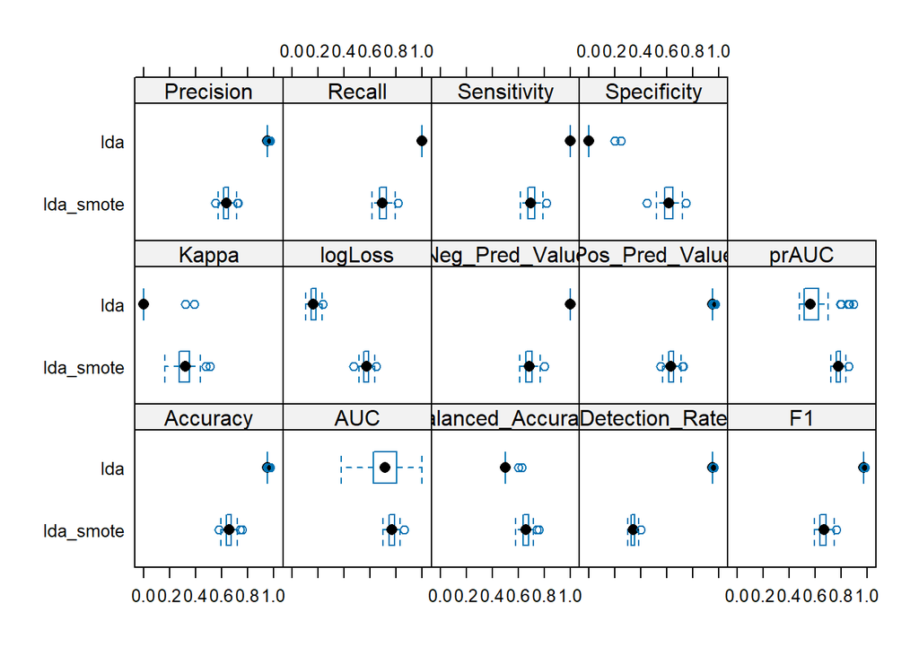

```r
# Boxplot for accuracy comparison
bwplot(results)
```

```r
# Pairwise comparisons
model_differences <- diff(results)
model_differences$statistics
```

```
$Accuracy
$Accuracy$lda.diff.lda_smote

    One Sample t-test

data:  x
t = 93.418, df = 99, p-value < 2.2e-16
alternative hypothesis: true mean is not equal to 0
95 percent confidence interval:
 0.2910244 0.3036555
sample estimates:
mean of x
  0.29734



$AUC
$AUC$lda.diff.lda_smote

    One Sample t-test

data:  x
t = -3.9681, df = 99, p-value = 0.0001373
alternative hypothesis: true mean is not equal to 0
95 percent confidence interval:
 -0.08249273 -0.02749407
sample estimates:
 mean of x
-0.0549934



$Balanced_Accuracy
$Balanced_Accuracy$lda.diff.lda_smote

    One Sample t-test

data:  x
t = -43.277, df = 99, p-value < 2.2e-16
alternative hypothesis: true mean is not equal to 0
```

[output cut: 166 more lines]

```


$Specificity
$Specificity$lda.diff.lda_smote

    One Sample t-test

data:  x
t = -104.44, df = 99, p-value < 2.2e-16
alternative hypothesis: true mean is not equal to 0
95 percent confidence interval:
 -0.6245395 -0.6012521
sample estimates:
 mean of x
-0.6128958
```

## Visualize the confusion matrix tables

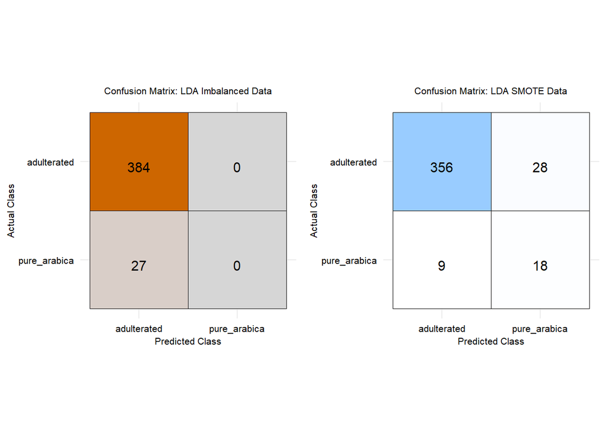

```r
# Imbalanced data
plt_Imb <- as.data.frame(test_lda_unmodified_CMtrx$table)
plt_Imb$Reference <- factor(plt_Imb$Reference, levels=rev(levels(plt_Imb$Reference)))

# SMOTE data
plt_smote <- as.data.frame(test_lda_smote_CMtrx$table)
plt_smote$Reference <- factor(plt_smote$Reference, levels=rev(levels(plt_smote$Reference)))


p1<-ggplot(plt_Imb, aes(y = Reference, x = Prediction, fill=Freq)) +
  geom_tile(aes(fill = Freq), color = "black") +
  geom_text(aes(label=Freq), vjust = 1,color = "black",size = 4) +
  scale_fill_gradient(low = "gray84", high = "darkorange3", name = "Frequency") +
  theme_minimal() +
  labs(x = "Predicted Class", y = "Actual Class", color = 'black',title = 'Confusion Matrix: LDA Imbalanced Data')+
  theme(
    legend.position =  "none",
    axis.text.y = element_text(color = "black",size = 8),
    axis.title.x  = element_text(size = 8),
    axis.text.x = element_text(color = "black",size = 8),
    axis.title.y = element_text(size = 8),aspect.ratio = 1,
    plot.title = element_text(size = 8,hjust = 0.5))


p2<-ggplot(plt_smote, aes(y = Reference, x = Prediction, fill=Freq)) +
  geom_tile(aes(fill = Freq), color = "black") +
  geom_text(aes(label=Freq), vjust = 1,color = "black",size = 4) +
  scale_fill_gradient(low = "white", high = "#99ccff", name = "Frequency") +
  theme_minimal() +
  labs(x = "Predicted Class", y = "Actual Class", color = 'black',title = 'Confusion Matrix: LDA SMOTE Data')+
  theme(
    legend.position =  "none",
    axis.text.y = element_text(color = "black",size = 8),
    axis.text.x = element_text(color = "black",size = 8),
    axis.title.x  = element_text(size = 8),
    axis.title.y = element_text(size = 8),aspect.ratio = 1,
    plot.title = element_text(size = 8,hjust = 0.5))

grid.arrange(p1,p2, nrow =1)
```

## ROC Curve

```r
#SMOTE data
# Generate the ROC curve
roc_curve <- roc(test_merged_smote_Preprocessed$binary_class,
                 as.numeric(test_lda_smote),
                 levels = c("adulterated", "pure_arabica"),
                 positive = 'adulterated')
```

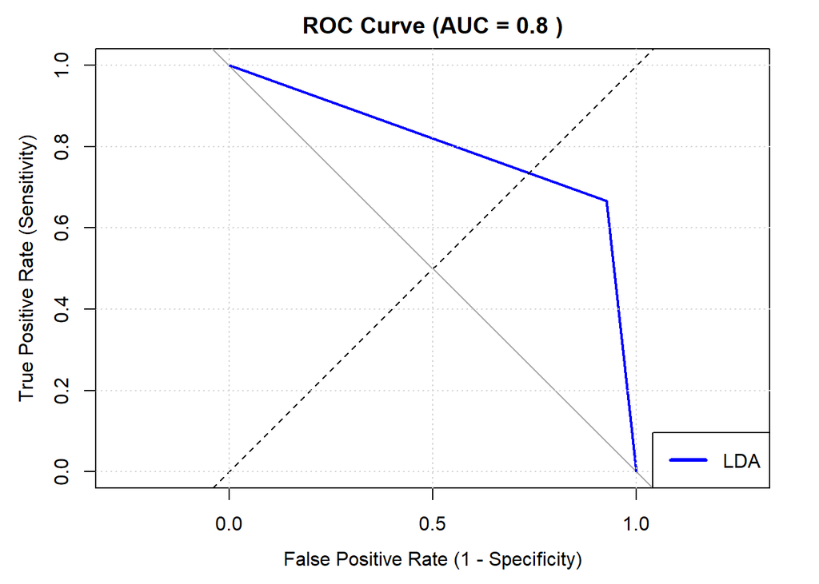

```r
# Calculate the AUC
auc_value <- auc(roc_curve)

# Plot the ROC curve
plot(roc_curve, col = 'blue', lwd = 2,
     main = paste("ROC Curve (AUC =", round(auc_value, 2), ")"),
     xlab = "False Positive Rate (1 - Specificity)",
     ylab = "True Positive Rate (Sensitivity)",
     xlim = c(0, 1), ylim = c(0, 1))
abline(a = 0, b = 1, lty = 2, col = "black")
grid(nx = NULL, ny = NULL, col = "lightgray", lty = "dotted")
legend("bottomright", legend = c("LDA"), col = 'blue', lwd = 3)
```

#### LDA Decision Boundary

```r
train_subset <- train_merged_smote_Preprocessed%>% dplyr::select(PC1,PC2,binary_class)

control_1 <- trainControl(method = "repeatedcv", number = 10, repeats = 10,
                        classProbs = TRUE, savePredictions = "final",
                        summaryFunction = multiClassSummary,
                        selectionFunction = 'oneSE')

lda_grid_fit <- train(binary_class~., data = train_subset,
                       method = 'lda',
                      metric = metric)
```

```r
# Create a grid of values
pc1_range <- seq(min(train_subset$PC1), max(train_subset$PC1), length.out = 100)
pc2_range <- seq(min(train_subset$PC2), max(train_subset$PC2), length.out = 100)

# Expand grid
grid_data <- expand.grid(PC1 = pc1_range, PC2 = pc2_range)

# Predict class probabilities for each point in the grid
grid_data$prediction <- predict(lda_grid_fit, newdata = grid_data)
grid_data$prediction <- as.factor(grid_data$prediction)
```

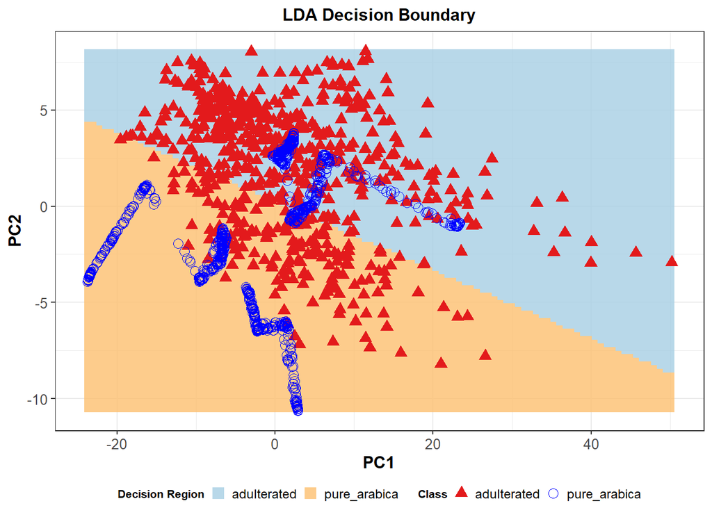

```r
ggplot() +
  geom_tile(data = grid_data, aes(x = PC1, y = PC2, fill = prediction), alpha = 0.8) +
  geom_point(data = train_subset, aes(x = PC1, y = PC2, color = binary_class, shape = binary_class), size = 3) +
  labs(
    title = "LDA Decision Boundary",
    x = "PC1",
    y = "PC2",
    color = "Class",
    fill = "Decision Region",
    shape = "Class"
  ) +
  theme_bw() +
  scale_fill_manual(values = c("#A6CEE3", "#FDBF6F")) +
  scale_color_manual(values = c("adulterated" = "#E31A1C", "pure_arabica" = "blue")) +
  scale_shape_manual(values = c("adulterated" = 17, "pure_arabica" = 21)) +
  theme(
    plot.title = element_text(hjust = 0.5, face = "bold", size = 12),
    axis.title = element_text(size = 12, face = "bold"),
    axis.text = element_text(size = 10),
    legend.position = "bottom",
    legend.direction = "horizontal",
    legend.box = "horizontal",
    legend.spacing.x = unit(0.1, 'cm'),
    legend.spacing.y = unit(0.1, 'cm'),
    legend.key.height = unit(0.2, "cm"),
    legend.key.width = unit(0.3, "cm"),
    legend.background = element_blank(),
    legend.box.margin = margin(-5, -5, -5, -5),
    legend.title = element_text(size = 8, face = "bold"),
    legend.text = element_text(size = 9)
  )
```

### Misclassifications

```r
## Imbalanced
observed <- y_test
predicted <- test_lda_unmodified
perc <- hsi_raw %>% filter(cal_val==2) %>% dplyr::select(perc_adulter)

imbal_class <- as.data.frame(cbind(observed,predicted,perc))
misclas_imbal <- imbal_class %>% filter(observed!=predicted)
misclas_imbal
```

```
       observed   predicted perc_adulter
1  pure_arabica adulterated            0
2  pure_arabica adulterated            0
3  pure_arabica adulterated            0
4  pure_arabica adulterated            0
5  pure_arabica adulterated            0
6  pure_arabica adulterated            0
7  pure_arabica adulterated            0
8  pure_arabica adulterated            0
9  pure_arabica adulterated            0
10 pure_arabica adulterated            0
11 pure_arabica adulterated            0
12 pure_arabica adulterated            0
13 pure_arabica adulterated            0
14 pure_arabica adulterated            0
15 pure_arabica adulterated            0
16 pure_arabica adulterated            0
17 pure_arabica adulterated            0
18 pure_arabica adulterated            0
19 pure_arabica adulterated            0
20 pure_arabica adulterated            0
21 pure_arabica adulterated            0
22 pure_arabica adulterated            0
23 pure_arabica adulterated            0
24 pure_arabica adulterated            0
25 pure_arabica adulterated            0
26 pure_arabica adulterated            0
27 pure_arabica adulterated            0
```

```r
table(misclas_imbal$perc_adulter)
```

```
 0
27
```

```r
# SMOTE Data
observed <- y_test
predicted <- test_lda_smote
perc <- hsi_raw %>% filter(cal_val==2) %>% dplyr::select(perc_adulter)

bal_class <- as.data.frame(cbind(observed,predicted,perc))
misclas_smote <- bal_class %>% filter(observed!=predicted)
misclas_smote
```

```
       observed    predicted perc_adulter
1  pure_arabica  adulterated            0
2  pure_arabica  adulterated            0
3  pure_arabica  adulterated            0
4  pure_arabica  adulterated            0
5  pure_arabica  adulterated            0
6  pure_arabica  adulterated            0
7  pure_arabica  adulterated            0
8  pure_arabica  adulterated            0
9  pure_arabica  adulterated            0
10  adulterated pure_arabica           10
11  adulterated pure_arabica           10
12  adulterated pure_arabica           10
13  adulterated pure_arabica            1
14  adulterated pure_arabica            1
```

[output cut: 23 more lines]

```r
table(misclas_smote$perc_adulter)
```

```
 0  1  5 10 20
 9  4 11  8  5
```